# Taller práctico de SQL Parte 2

Curso de Minería de Datos

Andrés Felipe Flórez Rivera

2026-04-13

Universidad Nacional de Colombia — Departamento de Estadística, Sede Bogotá

## Introducción

Esta clase es continuación directa del **Taller SQL Parte 1**. Partiendo del dominio de `SELECT`, `WHERE`, `GROUP BY` y las funciones de agregación, ahora incorporamos las herramientas que permiten combinar tablas, encadenar consultas y calcular métricas contextuales dentro de grupos, capacidades esenciales para el análisis descriptivo en bases de datos relacionales reales.

### Conexión a la base de datos Chinook

#### R

```r
library(DBI)
library(RSQLite)
library(dplyr)

con <- dbConnect(RSQLite::SQLite(), "../clase-4/chinook.db")
cat("Tablas disponibles:\n")
```

```
## Tablas disponibles:
```

```r
dbListTables(con)
```

```
##  [1] "Album"         "Artist"        "Customer"      "Employee"
##  [5] "Genre"         "Invoice"       "InvoiceLine"   "MediaType"
##  [9] "Playlist"      "PlaylistTrack" "Track"
```

#### Python

```python
import sqlite3
import pandas as pd

con = sqlite3.connect("../clase-4/chinook.db")
cur = con.cursor()
cur.execute("SELECT name FROM sqlite_master WHERE type='table' ORDER BY name;")
[row[0] for row in cur.fetchall()]
```

# 1. JOINs: Combinación de tablas

Un **JOIN** combina filas de dos o más tablas usando una condición de unión, generalmente la igualdad entre una llave primaria y una llave foránea.

## Tipos de JOIN y su comportamiento

| JOIN | Devuelve |
| --- | --- |
| `INNER JOIN` | Solo filas con coincidencia en **ambas** tablas |
| `LEFT JOIN` | Todas las filas de la tabla izquierda + coincidencias de la derecha (`NULL` si no hay) |
| `RIGHT JOIN` | Todas las filas de la tabla derecha + coincidencias de la izquierda (`NULL` si no hay) |
| `FULL OUTER JOIN` | Todas las filas de **ambas** tablas (`NULL` donde no hay coincidencia) |
| `CROSS JOIN` | Producto cartesiano: cada fila de la izquierda con cada fila de la derecha |
| `SELF JOIN` | La tabla se une consigo misma usando alias |

> **SQLite** soporta `INNER JOIN`, `LEFT JOIN`, `CROSS JOIN` y `SELF JOIN` de forma nativa. `RIGHT JOIN` y `FULL OUTER JOIN` **no están disponibles**, se simulan invirtiendo tablas o usando `UNION`.

## 1.1 INNER JOIN

Devuelve solo las filas que tienen coincidencia en ambas tablas. Es el join más común en análisis: garantiza que no haya nulos por falta de relación.

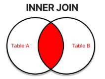

### Pistas con nombre de género

#### R

```r
resultado <- dbGetQuery(con, "
  SELECT t.Name                              AS pista,
         g.Name                              AS genero,
         ROUND(t.Milliseconds / 60000.0, 2) AS duracion_min,
         t.UnitPrice                         AS precio
  FROM   Track  t
  INNER JOIN Genre g ON t.GenreId = g.GenreId
  LIMIT  10;
")
mostrar_tabla(resultado, caption = "INNER JOIN: pistas con su género")
```

INNER JOIN: pistas con su género

| pista | genero | duracion_min | precio |
| --- | --- | --- | --- |
| For Those About To Rock (We Salute You) | Rock | 5.73 | 0.99 |
| Balls to the Wall | Rock | 5.71 | 0.99 |
| Fast As a Shark | Rock | 3.84 | 0.99 |
| Restless and Wild | Rock | 4.20 | 0.99 |
| Princess of the Dawn | Rock | 6.26 | 0.99 |
| Put The Finger On You | Rock | 3.43 | 0.99 |
| Let’s Get It Up | Rock | 3.90 | 0.99 |
| Inject The Venom | Rock | 3.51 | 0.99 |
| Snowballed | Rock | 3.39 | 0.99 |
| Evil Walks | Rock | 4.39 | 0.99 |

#### Python

```python
resultado = pd.read_sql_query("""
  SELECT t.Name                              AS pista,
         g.Name                              AS genero,
         ROUND(t.Milliseconds / 60000.0, 2) AS duracion_min,
         t.UnitPrice                         AS precio
  FROM   Track  t
  INNER JOIN Genre g ON t.GenreId = g.GenreId
  LIMIT  10;
""", con)
resultado
```

### JOIN múltiple: pista, álbum y artista

#### R

```r
resultado <- dbGetQuery(con, "
  SELECT ar.Name  AS artista,
         al.Title AS album,
         t.Name   AS pista,
         g.Name   AS genero
  FROM        Track   t
  INNER JOIN  Album   al ON t.AlbumId  = al.AlbumId
  INNER JOIN  Artist  ar ON al.ArtistId = ar.ArtistId
  INNER JOIN  Genre   g  ON t.GenreId  = g.GenreId
  LIMIT 10;
")
mostrar_tabla(resultado, caption = "JOIN múltiple: pista + álbum + artista + género")
```

JOIN múltiple: pista + álbum + artista + género

| artista | album | pista | genero |
| --- | --- | --- | --- |
| AC/DC | For Those About To Rock We Salute You | For Those About To Rock (We Salute You) | Rock |
| Accept | Balls to the Wall | Balls to the Wall | Rock |
| Accept | Restless and Wild | Fast As a Shark | Rock |
| Accept | Restless and Wild | Restless and Wild | Rock |
| Accept | Restless and Wild | Princess of the Dawn | Rock |
| AC/DC | For Those About To Rock We Salute You | Put The Finger On You | Rock |
| AC/DC | For Those About To Rock We Salute You | Let’s Get It Up | Rock |
| AC/DC | For Those About To Rock We Salute You | Inject The Venom | Rock |
| AC/DC | For Those About To Rock We Salute You | Snowballed | Rock |
| AC/DC | For Those About To Rock We Salute You | Evil Walks | Rock |

#### Python

```python
resultado = pd.read_sql_query("""
  SELECT ar.Name  AS artista,
         al.Title AS album,
         t.Name   AS pista,
         g.Name   AS genero
  FROM        Track   t
  INNER JOIN  Album   al ON t.AlbumId   = al.AlbumId
  INNER JOIN  Artist  ar ON al.ArtistId = ar.ArtistId
  INNER JOIN  Genre   g  ON t.GenreId   = g.GenreId
  LIMIT 10;
""", con)
resultado
```

## 1.2 LEFT JOIN

Devuelve **todas** las filas de la tabla izquierda aunque no tengan coincidencia en la derecha. Las columnas de la tabla derecha aparecen como `NULL` cuando no hay match. Es ideal para detectar registros huérfanos.

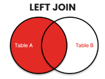

### Artistas sin álbumes en la base de datos

#### R

```r
resultado <- dbGetQuery(con, "
  SELECT ar.Name   AS artista,
         al.Title  AS album
  FROM   Artist ar
  LEFT JOIN Album al ON ar.ArtistId = al.ArtistId
  WHERE  al.AlbumId IS NULL   -- artistas sin álbum registrado
  LIMIT  10;
")
mostrar_tabla(resultado, caption = "LEFT JOIN: artistas sin álbumes")
```

LEFT JOIN: artistas sin álbumes

| artista | album |
| --- | --- |
| Milton Nascimento & Bebeto | NA |
| Azymuth | NA |
| João Gilberto | NA |
| Bebel Gilberto | NA |
| Jorge Vercilo | NA |
| Baby Consuelo | NA |
| Ney Matogrosso | NA |
| Luiz Melodia | NA |
| Nando Reis | NA |
| Pedro Luís & A Parede | NA |

#### Python

```python
resultado = pd.read_sql_query("""
  SELECT ar.Name   AS artista,
         al.Title  AS album
  FROM   Artist ar
  LEFT JOIN Album al ON ar.ArtistId = al.ArtistId
  WHERE  al.AlbumId IS NULL
  LIMIT  10;
""", con)
resultado
```

### Todos los artistas con conteo de álbumes (incluyendo los que tienen cero)

#### R

```r
resultado <- dbGetQuery(con, "
  SELECT   ar.Name        AS artista,
           COUNT(al.AlbumId) AS n_albums
  FROM     Artist ar
  LEFT JOIN Album al ON ar.ArtistId = al.ArtistId
  GROUP BY ar.ArtistId, ar.Name
  ORDER BY n_albums DESC
  LIMIT    15;
")
mostrar_tabla(resultado, caption = "LEFT JOIN: artistas y su número de álbumes")
```

LEFT JOIN: artistas y su número de álbumes

| artista | n_albums |
| --- | --- |
| Iron Maiden | 21 |
| Led Zeppelin | 14 |
| Deep Purple | 11 |
| Metallica | 10 |
| U2 | 10 |
| Ozzy Osbourne | 6 |
| Pearl Jam | 5 |
| Various Artists | 4 |
| Faith No More | 4 |
| Foo Fighters | 4 |

#### Python

```python
resultado = pd.read_sql_query("""
  SELECT   ar.Name           AS artista,
           COUNT(al.AlbumId) AS n_albums
  FROM     Artist ar
  LEFT JOIN Album al ON ar.ArtistId = al.ArtistId
  GROUP BY ar.ArtistId, ar.Name
  ORDER BY n_albums DESC
  LIMIT    15;
""", con)
resultado
```

## 1.3 RIGHT JOIN y FULL OUTER JOIN

> **SQLite no soporta `RIGHT JOIN` ni `FULL OUTER JOIN`.** Se simulan de la siguiente forma:

| Join deseado | Solución en SQLite |
| --- | --- |
| `RIGHT JOIN A ON ...` | Invertir: `LEFT JOIN` poniendo la tabla derecha a la izquierda |
| `FULL OUTER JOIN` | `LEFT JOIN` + `UNION ALL` + `LEFT JOIN` invertido filtrando nulos |

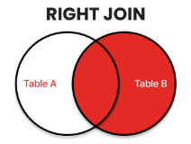

### RIGHT JOIN: simulación en SQLite

#### R

```r
# SQLite no tiene RIGHT JOIN: se invierte el orden de las tablas con LEFT JOIN
resultado <- dbGetQuery(con, "
  SELECT al.Title  AS album,
         ar.Name   AS artista
  FROM   Album  al
  LEFT JOIN Artist ar ON al.ArtistId = ar.ArtistId
  LIMIT  10;
")
mostrar_tabla(resultado, caption = "RIGHT JOIN simulado en SQLite con LEFT JOIN invertido")
```

RIGHT JOIN simulado en SQLite con LEFT JOIN invertido

| album | artista |
| --- | --- |
| For Those About To Rock We Salute You | AC/DC |
| Balls to the Wall | Accept |
| Restless and Wild | Accept |
| Let There Be Rock | AC/DC |
| Big Ones | Aerosmith |
| Jagged Little Pill | Alanis Morissette |
| Facelift | Alice In Chains |
| Warner 25 Anos | Antônio Carlos Jobim |
| Plays Metallica By Four Cellos | Apocalyptica |
| Audioslave | Audioslave |

#### Python

```python
resultado = pd.read_sql_query("""
  SELECT al.Title  AS album,
         ar.Name   AS artista
  FROM   Album  al
  LEFT JOIN Artist ar ON al.ArtistId = ar.ArtistId
  LIMIT  10;
""", con)
resultado
```

> **Sintaxis nativa en MySQL, PostgreSQL, SQL Server, BigQuery y Snowflake:** estos motores soportan `RIGHT JOIN` directamente sin necesidad de invertir las tablas.

> ```sql
> SELECT al.Title  AS album,
>        ar.Name   AS artista
> FROM   Artist ar
> RIGHT JOIN Album al ON ar.ArtistId = al.ArtistId
> LIMIT  10;
> ```

### FULL OUTER JOIN: simulación en SQLite

#### R

```r
# SQLite no tiene FULL OUTER JOIN:
# se simula con LEFT JOIN + UNION ALL + LEFT JOIN invertido
resultado <- dbGetQuery(con, "
  SELECT ar.Name  AS artista,
         al.Title AS album
  FROM   Artist ar
  LEFT JOIN Album al ON ar.ArtistId = al.ArtistId

  UNION ALL

  SELECT ar.Name  AS artista,
         al.Title AS album
  FROM   Album al
  LEFT JOIN Artist ar ON al.ArtistId = ar.ArtistId
  WHERE  ar.ArtistId IS NULL
  LIMIT  15;
")
mostrar_tabla(resultado, caption = "FULL OUTER JOIN simulado en SQLite")
```

FULL OUTER JOIN simulado en SQLite

| artista | album |
| --- | --- |
| AC/DC | For Those About To Rock We Salute You |
| AC/DC | Let There Be Rock |
| Accept | Balls to the Wall |
| Accept | Restless and Wild |
| Aerosmith | Big Ones |
| Alanis Morissette | Jagged Little Pill |
| Alice In Chains | Facelift |
| Antônio Carlos Jobim | Warner 25 Anos |
| Antônio Carlos Jobim | Chill: Brazil (Disc 2) |
| Apocalyptica | Plays Metallica By Four Cellos |

#### Python

```python
resultado = pd.read_sql_query("""
  SELECT ar.Name  AS artista,
         al.Title AS album
  FROM   Artist ar
  LEFT JOIN Album al ON ar.ArtistId = al.ArtistId

  UNION ALL

  SELECT ar.Name  AS artista,
         al.Title AS album
  FROM   Album al
  LEFT JOIN Artist ar ON al.ArtistId = ar.ArtistId
  WHERE  ar.ArtistId IS NULL
  LIMIT  15;
""", con)
resultado
```

> **Sintaxis nativa en PostgreSQL, SQL Server, BigQuery y Snowflake:** soportan `FULL OUTER JOIN` directamente. MySQL no lo soporta y requiere la misma simulación con `UNION ALL`.

> ```sql
> SELECT ar.Name  AS artista,
>        al.Title AS album
> FROM   Artist ar
> FULL OUTER JOIN Album al ON ar.ArtistId = al.ArtistId;
> ```

## 1.4 CROSS JOIN

Produce el **producto cartesiano**: cada fila de la tabla A se combina con cada fila de la tabla B. Si A tiene $m$ filas y B tiene $n$ filas, el resultado tiene $m \times n$ filas. Útil para generar combinaciones o matrices de referencia.

### Todas las combinaciones de género y tipo de medio

#### R

```r
resultado <- dbGetQuery(con, "
  SELECT g.Name  AS genero,
         m.Name  AS tipo_medio
  FROM   Genre     g
  CROSS JOIN MediaType m
  ORDER BY g.Name, m.Name
  LIMIT  15;
")
mostrar_tabla(resultado, caption = "CROSS JOIN: géneros × tipos de medio")
```

CROSS JOIN: géneros × tipos de medio

| genero | tipo_medio |
| --- | --- |
| Alternative | AAC audio file |
| Alternative | MPEG audio file |
| Alternative | Protected AAC audio file |
| Alternative | Protected MPEG-4 video file |
| Alternative | Purchased AAC audio file |
| Alternative & Punk | AAC audio file |
| Alternative & Punk | MPEG audio file |
| Alternative & Punk | Protected AAC audio file |
| Alternative & Punk | Protected MPEG-4 video file |
| Alternative & Punk | Purchased AAC audio file |

#### Python

```python
resultado = pd.read_sql_query("""
  SELECT g.Name  AS genero,
         m.Name  AS tipo_medio
  FROM   Genre     g
  CROSS JOIN MediaType m
  ORDER BY g.Name, m.Name
  LIMIT  15;
""", con)
resultado
```

## 1.5 SELF JOIN

Una tabla se une **consigo misma** usando dos alias distintos. El caso clásico es una tabla de empleados donde cada empleado tiene un campo `ReportsTo` que apunta al `EmployeeId` de su jefe.

### Empleados y sus supervisores

#### R

```r
resultado <- dbGetQuery(con, "
  SELECT e.FirstName || ' ' || e.LastName   AS empleado,
         e.Title                             AS cargo,
         m.FirstName || ' ' || m.LastName   AS supervisor
  FROM   Employee e
  LEFT JOIN Employee m ON e.ReportsTo = m.EmployeeId
  ORDER BY supervisor, empleado;
")
mostrar_tabla(resultado, caption = "SELF JOIN: empleados y sus supervisores")
```

SELF JOIN: empleados y sus supervisores

| empleado | cargo | supervisor |
| --- | --- | --- |
| Andrew Adams | General Manager | NA |
| Michael Mitchell | IT Manager | Andrew Adams |
| Nancy Edwards | Sales Manager | Andrew Adams |
| Laura Callahan | IT Staff | Michael Mitchell |
| Robert King | IT Staff | Michael Mitchell |
| Jane Peacock | Sales Support Agent | Nancy Edwards |
| Margaret Park | Sales Support Agent | Nancy Edwards |
| Steve Johnson | Sales Support Agent | Nancy Edwards |

#### Python

```python
resultado = pd.read_sql_query("""
  SELECT e.FirstName || ' ' || e.LastName   AS empleado,
         e.Title                             AS cargo,
         m.FirstName || ' ' || m.LastName   AS supervisor
  FROM   Employee e
  LEFT JOIN Employee m ON e.ReportsTo = m.EmployeeId
  ORDER BY supervisor, empleado;
""", con)
resultado
```

# 2. Operadores de conjunto

Los operadores de conjunto combinan los resultados de dos o más consultas. Las columnas deben ser **compatibles en número y tipo**.

| Operador | Resultado | Duplicados |
| --- | --- | --- |
| `UNION` | Filas de A + filas de B | Elimina duplicados |
| `UNION ALL` | Filas de A + filas de B | Conserva duplicados |
| `INTERSECT` | Solo filas presentes en **ambas** consultas | Elimina duplicados |
| `EXCEPT` | Filas de A que **no** están en B | Elimina duplicados |

## 2.1 UNION y UNION ALL

### Clientes de Brasil y de Canadá en una sola lista

#### R

```r
resultado <- dbGetQuery(con, "
  SELECT FirstName || ' ' || LastName AS cliente, Country AS pais
  FROM   Customer
  WHERE  Country = 'Brazil'

  UNION ALL

  SELECT FirstName || ' ' || LastName, Country
  FROM   Customer
  WHERE  Country = 'Canada'
  ORDER BY pais, cliente;
")
mostrar_tabla(resultado, caption = "UNION ALL: clientes de Brasil y Canadá")
```

UNION ALL: clientes de Brasil y Canadá

| cliente | pais |
| --- | --- |
| Alexandre Rocha | Brazil |
| Eduardo Martins | Brazil |
| Fernanda Ramos | Brazil |
| Luís Gonçalves | Brazil |
| Roberto Almeida | Brazil |
| Aaron Mitchell | Canada |
| Edward Francis | Canada |
| Ellie Sullivan | Canada |
| François Tremblay | Canada |
| Jennifer Peterson | Canada |

#### Python

```python
resultado = pd.read_sql_query("""
  SELECT FirstName || ' ' || LastName AS cliente, Country AS pais
  FROM   Customer
  WHERE  Country = 'Brazil'

  UNION ALL

  SELECT FirstName || ' ' || LastName, Country
  FROM   Customer
  WHERE  Country = 'Canada'
  ORDER BY pais, cliente;
""", con)
resultado
```

## 2.2 INTERSECT

### Géneros que tienen pistas en más de un tipo de medio

#### R

```r
resultado <- dbGetQuery(con, "
  -- Géneros que aparecen en MediaTypeId = 1
  SELECT DISTINCT GenreId FROM Track WHERE MediaTypeId = 1

  INTERSECT

  -- Géneros que también aparecen en MediaTypeId = 2
  SELECT DISTINCT GenreId FROM Track WHERE MediaTypeId = 2;
")
mostrar_tabla(resultado, caption = "INTERSECT: géneros en MediaType 1 y 2")
```

INTERSECT: géneros en MediaType 1 y 2

| GenreId |
| --- |
| 1 |
| 9 |
| 10 |
| 14 |

#### Python

```python
resultado = pd.read_sql_query("""
  SELECT DISTINCT GenreId FROM Track WHERE MediaTypeId = 1
  INTERSECT
  SELECT DISTINCT GenreId FROM Track WHERE MediaTypeId = 2;
""", con)
resultado
```

## 2.3 EXCEPT

### Artistas que tienen álbumes pero ninguna pista vendida

#### R

```r
resultado <- dbGetQuery(con, "
  -- Todos los artistas con al menos un álbum
  SELECT DISTINCT al.ArtistId
  FROM   Album al

  EXCEPT

  -- Artistas cuyas pistas aparecen en alguna factura
  SELECT DISTINCT al.ArtistId
  FROM   Album       al
  JOIN   Track       t  ON al.AlbumId    = t.AlbumId
  JOIN   InvoiceLine il ON t.TrackId     = il.TrackId
  LIMIT  10;
")
mostrar_tabla(resultado, caption = "EXCEPT: artistas con álbumes pero sin ventas")
```

EXCEPT: artistas con álbumes pero sin ventas

| ArtistId |
| --- |
| 196 |
| 197 |
| 199 |
| 202 |
| 203 |
| 206 |
| 207 |
| 209 |
| 210 |
| 211 |

#### Python

```python
resultado = pd.read_sql_query("""
  SELECT DISTINCT al.ArtistId
  FROM   Album al

  EXCEPT

  SELECT DISTINCT al.ArtistId
  FROM   Album       al
  JOIN   Track       t  ON al.AlbumId = t.AlbumId
  JOIN   InvoiceLine il ON t.TrackId  = il.TrackId
  LIMIT  10;
""", con)
resultado
```

# 3. Subconsultas

Una **subconsulta** es una consulta anidada dentro de otra. Según su posición tiene un nombre y uso diferente.

| Posición | Nombre | Uso |
| --- | --- | --- |
| `WHERE col = (SELECT ...)` | Subconsulta escalar | Comparar con un valor calculado |
| `WHERE col IN (SELECT ...)` | Subconsulta de lista | Filtrar con un conjunto dinámico |
| `FROM (SELECT ...) alias` | Tabla derivada | Usar el resultado como tabla |
| `WHERE col = (SELECT ... WHERE t.col = outer.col)` | Subconsulta correlacionada | Referencia a la consulta externa |

## 3.1 Subconsulta en WHERE

### Pistas con precio superior al precio medio

#### R

```r
resultado <- dbGetQuery(con, "
  SELECT Name        AS pista,
         UnitPrice   AS precio
  FROM   Track
  WHERE  UnitPrice > (SELECT AVG(UnitPrice) FROM Track)
  ORDER  BY UnitPrice DESC
  LIMIT  10;
")
mostrar_tabla(resultado, caption = "Subconsulta: pistas más caras que el promedio")
```

Subconsulta: pistas más caras que el promedio

| pista | precio |
| --- | --- |
| Battlestar Galactica: The Story So Far | 1.99 |
| Occupation / Precipice | 1.99 |
| Exodus, Pt. 1 | 1.99 |
| Exodus, Pt. 2 | 1.99 |
| Collaborators | 1.99 |
| Torn | 1.99 |
| A Measure of Salvation | 1.99 |
| Hero | 1.99 |
| Unfinished Business | 1.99 |
| The Passage | 1.99 |

#### Python

```python
resultado = pd.read_sql_query("""
  SELECT Name        AS pista,
         UnitPrice   AS precio
  FROM   Track
  WHERE  UnitPrice > (SELECT AVG(UnitPrice) FROM Track)
  ORDER  BY UnitPrice DESC
  LIMIT  10;
""", con)
resultado
```

## 3.2 Tabla derivada en FROM

### Promedio de ventas por cliente, agrupado por país

#### R

```r
resultado <- dbGetQuery(con, "
  SELECT pais,
         ROUND(AVG(total_cliente), 2) AS gasto_medio_por_cliente,
         COUNT(*)                     AS n_clientes
  FROM (
    SELECT c.Country          AS pais,
           SUM(i.Total)       AS total_cliente
    FROM   Customer c
    JOIN   Invoice  i ON c.CustomerId = i.CustomerId
    GROUP BY c.CustomerId, c.Country
  ) resumen
  GROUP BY pais
  ORDER BY gasto_medio_por_cliente DESC
  LIMIT  10;
")
mostrar_tabla(resultado, caption = "Tabla derivada: gasto medio por cliente, por país")
```

Tabla derivada: gasto medio por cliente, por país

| pais | gasto_medio_por_cliente | n_clientes |
| --- | --- | --- |
| Chile | 46.62 | 1 |
| Ireland | 45.62 | 1 |
| Hungary | 45.62 | 1 |
| Czech Republic | 45.12 | 2 |
| Austria | 42.62 | 1 |
| Finland | 41.62 | 1 |
| Netherlands | 40.62 | 1 |
| USA | 40.24 | 13 |
| Norway | 39.62 | 1 |
| Germany | 39.12 | 4 |

#### Python

```python
resultado = pd.read_sql_query("""
  SELECT pais,
         ROUND(AVG(total_cliente), 2) AS gasto_medio_por_cliente,
         COUNT(*)                     AS n_clientes
  FROM (
    SELECT c.Country    AS pais,
           SUM(i.Total) AS total_cliente
    FROM   Customer c
    JOIN   Invoice  i ON c.CustomerId = i.CustomerId
    GROUP BY c.CustomerId, c.Country
  ) resumen
  GROUP BY pais
  ORDER BY gasto_medio_por_cliente DESC
  LIMIT  10;
""", con)
resultado
```

## 3.3 Subconsulta correlacionada

La subconsulta hace referencia a la consulta exterior. Se ejecuta **una vez por cada fila** de la consulta externa, puede ser costosa, pero es muy expresiva.

### Clientes que gastaron más que el promedio de su país

#### R

```r
resultado <- dbGetQuery(con, "
  SELECT c.FirstName || ' ' || c.LastName AS cliente,
         c.Country                         AS pais,
         ROUND(SUM(i.Total), 2)            AS gasto_total
  FROM   Customer c
  JOIN   Invoice  i ON c.CustomerId = i.CustomerId
  GROUP BY c.CustomerId
  HAVING SUM(i.Total) > (
    -- promedio de gasto de los clientes del mismo país
    SELECT AVG(sub_total)
    FROM (
      SELECT SUM(i2.Total) AS sub_total
      FROM   Customer c2
      JOIN   Invoice  i2 ON c2.CustomerId = i2.CustomerId
      WHERE  c2.Country = c.Country
      GROUP BY c2.CustomerId
    )
  )
  ORDER BY pais, gasto_total DESC;
")
mostrar_tabla(resultado, caption = "Clientes que gastaron más que el promedio de su país")
```

Clientes que gastaron más que el promedio de su país

| cliente | pais | gasto_total |
| --- | --- | --- |
| Luís Gonçalves | Brazil | 39.62 |
| François Tremblay | Canada | 39.62 |
| Jennifer Peterson | Canada | 38.62 |
| Helena Holý | Czech Republic | 49.62 |
| Isabelle Mercier | France | 40.62 |
| Wyatt Girard | France | 39.62 |
| Fynn Zimmermann | Germany | 43.62 |
| Manoj Pareek | India | 38.62 |
| João Fernandes | Portugal | 39.62 |
| Richard Cunningham | USA | 47.62 |

#### Python

```python
resultado = pd.read_sql_query("""
  SELECT c.FirstName || ' ' || c.LastName AS cliente,
         c.Country                         AS pais,
         ROUND(SUM(i.Total), 2)            AS gasto_total
  FROM   Customer c
  JOIN   Invoice  i ON c.CustomerId = i.CustomerId
  GROUP BY c.CustomerId
  HAVING SUM(i.Total) > (
    SELECT AVG(sub_total)
    FROM (
      SELECT SUM(i2.Total) AS sub_total
      FROM   Customer c2
      JOIN   Invoice  i2 ON c2.CustomerId = i2.CustomerId
      WHERE  c2.Country = c.Country
      GROUP BY c2.CustomerId
    )
  )
  ORDER BY pais, gasto_total DESC;
""", con)
resultado
```

# 4. CTEs: Common Table Expressions (`WITH`)

Una **CTE** (expresión de tabla común) nombra una subconsulta para reutilizarla dentro de la misma consulta. Hace el código más legible, permite encadenar pasos de transformación y evita repetir subconsultas.

```sql
WITH nombre_cte AS (
  SELECT ...
),
otra_cte AS (
  SELECT ... FROM nombre_cte ...
)
SELECT ... FROM otra_cte;
```

> SQLite soporta CTEs desde la versión 3.8.3 (2014). Todos los motores modernos las soportan.

## 4.1 CTE simple

#### R

```r
resultado <- dbGetQuery(con, "
  WITH gasto_cliente AS (
    SELECT c.CustomerId,
           c.FirstName || ' ' || c.LastName AS cliente,
           c.Country,
           ROUND(SUM(i.Total), 2)           AS gasto_total
    FROM   Customer c
    JOIN   Invoice  i ON c.CustomerId = i.CustomerId
    GROUP BY c.CustomerId
  )
  SELECT cliente, Country AS pais, gasto_total
  FROM   gasto_cliente
  ORDER  BY gasto_total DESC
  LIMIT  10;
")
mostrar_tabla(resultado, caption = "CTE: top 10 clientes por gasto total")
```

CTE: top 10 clientes por gasto total

| cliente | pais | gasto_total |
| --- | --- | --- |
| Helena Holý | Czech Republic | 49.62 |
| Richard Cunningham | USA | 47.62 |
| Luis Rojas | Chile | 46.62 |
| Ladislav Kovács | Hungary | 45.62 |
| Hugh O’Reilly | Ireland | 45.62 |
| Frank Ralston | USA | 43.62 |
| Julia Barnett | USA | 43.62 |
| Fynn Zimmermann | Germany | 43.62 |
| Astrid Gruber | Austria | 42.62 |
| Victor Stevens | USA | 42.62 |

#### Python

```python
resultado = pd.read_sql_query("""
  WITH gasto_cliente AS (
    SELECT c.CustomerId,
           c.FirstName || ' ' || c.LastName AS cliente,
           c.Country,
           ROUND(SUM(i.Total), 2)           AS gasto_total
    FROM   Customer c
    JOIN   Invoice  i ON c.CustomerId = i.CustomerId
    GROUP BY c.CustomerId
  )
  SELECT cliente, Country AS pais, gasto_total
  FROM   gasto_cliente
  ORDER  BY gasto_total DESC
  LIMIT  10;
""", con)
resultado
```

## 4.2 CTEs encadenadas

Cada CTE puede referenciar a las CTEs anteriores en la misma cláusula `WITH`.

### Géneros con más ingresos, comparados contra el promedio general

#### R

```r
resultado <- dbGetQuery(con, "
  WITH ventas_por_genero AS (
    SELECT   g.Name             AS genero,
             SUM(il.UnitPrice * il.Quantity) AS ingresos
    FROM     InvoiceLine il
    JOIN     Track  t  ON il.TrackId  = t.TrackId
    JOIN     Genre  g  ON t.GenreId   = g.GenreId
    GROUP BY g.Name
  ),
  promedio_global AS (
    SELECT AVG(ingresos) AS media_ingresos
    FROM   ventas_por_genero
  )
  SELECT v.genero,
         ROUND(v.ingresos, 2)      AS ingresos,
         ROUND(p.media_ingresos, 2) AS media_global,
         CASE
           WHEN v.ingresos > p.media_ingresos THEN 'sobre promedio'
           ELSE 'bajo promedio'
         END AS desempeno
  FROM ventas_por_genero v, promedio_global p
  ORDER BY ingresos DESC;
")
mostrar_tabla(resultado, caption = "CTE encadenada: ingresos por género vs. promedio")
```

CTE encadenada: ingresos por género vs. promedio

| genero | ingresos | media_global | desempeno |
| --- | --- | --- | --- |
| Rock | 826.65 | 97.02 | sobre promedio |
| Latin | 382.14 | 97.02 | sobre promedio |
| Metal | 261.36 | 97.02 | sobre promedio |
| Alternative & Punk | 241.56 | 97.02 | sobre promedio |
| TV Shows | 93.53 | 97.02 | bajo promedio |
| Jazz | 79.20 | 97.02 | bajo promedio |
| Blues | 60.39 | 97.02 | bajo promedio |
| Drama | 57.71 | 97.02 | bajo promedio |
| Classical | 40.59 | 97.02 | bajo promedio |
| R&B/Soul | 40.59 | 97.02 | bajo promedio |

#### Python

```python
resultado = pd.read_sql_query("""
  WITH ventas_por_genero AS (
    SELECT   g.Name                          AS genero,
             SUM(il.UnitPrice * il.Quantity) AS ingresos
    FROM     InvoiceLine il
    JOIN     Track  t ON il.TrackId = t.TrackId
    JOIN     Genre  g ON t.GenreId  = g.GenreId
    GROUP BY g.Name
  ),
  promedio_global AS (
    SELECT AVG(ingresos) AS media_ingresos
    FROM   ventas_por_genero
  )
  SELECT v.genero,
         ROUND(v.ingresos, 2)       AS ingresos,
         ROUND(p.media_ingresos, 2) AS media_global,
         CASE
           WHEN v.ingresos > p.media_ingresos THEN 'sobre promedio'
           ELSE 'bajo promedio'
         END AS desempeno
  FROM ventas_por_genero v, promedio_global p
  ORDER BY ingresos DESC;
""", con)
resultado
```

# 5. Funciones de ventana: `OVER` y `PARTITION BY`

Las **funciones de ventana** calculan un valor para cada fila usando un conjunto de filas relacionadas (la “ventana”), **sin colapsar el resultado** como lo hace `GROUP BY`. Permiten calcular rankings, totales acumulados, diferencias entre filas y percentiles dentro de grupos.

```sql
funcion() OVER (
  PARTITION BY columna_grupo   -- define los grupos (como GROUP BY, pero sin colapsar)
  ORDER BY     columna_orden   -- define el orden dentro de cada grupo
  ROWS/RANGE BETWEEN ...       -- opcional: tamaño de la ventana deslizante
)
```

> SQLite soporta funciones de ventana desde la versión **3.25.0 (2018)**.

| Función | Descripción |
| --- | --- |
| `ROW_NUMBER()` | Número de fila dentro de la ventana (sin empates) |
| `RANK()` | Posición con saltos en caso de empate |
| `DENSE_RANK()` | Posición sin saltos en empates |
| `NTILE(n)` | Divide en `n` grupos de igual tamaño (cuantiles) |
| `LAG(col, n)` | Valor de la fila `n` posiciones antes |
| `LEAD(col, n)` | Valor de la fila `n` posiciones después |
| `FIRST_VALUE(col)` | Primer valor de la ventana |
| `LAST_VALUE(col)` | Último valor de la ventana |
| `SUM / AVG / COUNT OVER` | Agregado acumulado o por partición |

## 5.1 ROW_NUMBER: numeración de filas

### Ranking de pistas por duración dentro de cada género

#### R

```r
resultado <- dbGetQuery(con, "
  SELECT g.Name                              AS genero,
         t.Name                              AS pista,
         ROUND(t.Milliseconds/60000.0, 2)   AS duracion_min,
         ROW_NUMBER() OVER (
           PARTITION BY t.GenreId
           ORDER BY     t.Milliseconds DESC
         )                                   AS ranking_duracion
  FROM   Track t
  JOIN   Genre g ON t.GenreId = g.GenreId
  ORDER  BY genero, ranking_duracion
  LIMIT  15;
")
mostrar_tabla(resultado, caption = "ROW_NUMBER: ranking de duración por género")
```

ROW_NUMBER: ranking de duración por género

| genero | pista | duracion_min | ranking_duracion |
| --- | --- | --- | --- |
| Alternative | Reach Down | 11.21 | 1 |
| Alternative | Four Walled World | 6.91 | 2 |
| Alternative | Say Hello 2 Heaven | 6.41 | 3 |
| Alternative | Times of Trouble | 5.71 | 4 |
| Alternative | Call Me a Dog | 5.07 | 5 |
| Alternative | Show Me How to Live (Live at the Quart Festival) | 5.03 | 6 |
| Alternative | Moth | 4.97 | 7 |
| Alternative | Band Members Discuss Tracks from “Revelations” | 4.90 | 8 |
| Alternative | Billie Jean | 4.69 | 9 |
| Alternative | Shape of Things to Come | 4.58 | 10 |

#### Python

```python
resultado = pd.read_sql_query("""
  SELECT g.Name                              AS genero,
         t.Name                              AS pista,
         ROUND(t.Milliseconds/60000.0, 2)   AS duracion_min,
         ROW_NUMBER() OVER (
           PARTITION BY t.GenreId
           ORDER BY     t.Milliseconds DESC
         )                                   AS ranking_duracion
  FROM   Track t
  JOIN   Genre g ON t.GenreId = g.GenreId
  ORDER  BY genero, ranking_duracion
  LIMIT  15;
""", con)
resultado
```

## 5.2 RANK y DENSE_RANK

`RANK()` deja huecos cuando hay empate (1, 2, 2, **4**…); `DENSE_RANK()` no los deja (1, 2, 2, **3**…).

### Ranking de clientes por gasto total

#### R

```r
resultado <- dbGetQuery(con, "
  WITH gasto AS (
    SELECT c.FirstName || ' ' || c.LastName AS cliente,
           c.Country,
           ROUND(SUM(i.Total), 2)           AS gasto_total
    FROM   Customer c
    JOIN   Invoice  i ON c.CustomerId = i.CustomerId
    GROUP BY c.CustomerId
  )
  SELECT cliente,
         Country                                        AS pais,
         gasto_total,
         RANK()       OVER (ORDER BY gasto_total DESC) AS rank_con_huecos,
         DENSE_RANK() OVER (ORDER BY gasto_total DESC) AS rank_sin_huecos
  FROM   gasto
  ORDER  BY gasto_total DESC
  LIMIT  12;
")
mostrar_tabla(resultado, caption = "RANK vs DENSE_RANK: clientes por gasto")
```

RANK vs DENSE_RANK: clientes por gasto

| cliente | pais | gasto_total | rank_con_huecos | rank_sin_huecos |
| --- | --- | --- | --- | --- |
| Helena Holý | Czech Republic | 49.62 | 1 | 1 |
| Richard Cunningham | USA | 47.62 | 2 | 2 |
| Luis Rojas | Chile | 46.62 | 3 | 3 |
| Ladislav Kovács | Hungary | 45.62 | 4 | 4 |
| Hugh O’Reilly | Ireland | 45.62 | 4 | 4 |
| Frank Ralston | USA | 43.62 | 6 | 5 |
| Julia Barnett | USA | 43.62 | 6 | 5 |
| Fynn Zimmermann | Germany | 43.62 | 6 | 5 |
| Astrid Gruber | Austria | 42.62 | 9 | 6 |
| Victor Stevens | USA | 42.62 | 9 | 6 |

#### Python

```python
resultado = pd.read_sql_query("""
  WITH gasto AS (
    SELECT c.FirstName || ' ' || c.LastName AS cliente,
           c.Country,
           ROUND(SUM(i.Total), 2)           AS gasto_total
    FROM   Customer c
    JOIN   Invoice  i ON c.CustomerId = i.CustomerId
    GROUP BY c.CustomerId
  )
  SELECT cliente,
         Country                                        AS pais,
         gasto_total,
         RANK()       OVER (ORDER BY gasto_total DESC) AS rank_con_huecos,
         DENSE_RANK() OVER (ORDER BY gasto_total DESC) AS rank_sin_huecos
  FROM   gasto
  ORDER  BY gasto_total DESC
  LIMIT  12;
""", con)
resultado
```

## 5.3 NTILE: cuartiles y percentiles

`NTILE(n)` divide las filas en `n` grupos de igual tamaño. `NTILE(4)` genera cuartiles; `NTILE(10)` genera deciles.

### Cuartiles de gasto entre clientes

#### R

```r
resultado <- dbGetQuery(con, "
  WITH gasto AS (
    SELECT c.FirstName || ' ' || c.LastName AS cliente,
           ROUND(SUM(i.Total), 2)           AS gasto_total
    FROM   Customer c
    JOIN   Invoice  i ON c.CustomerId = i.CustomerId
    GROUP BY c.CustomerId
  )
  SELECT cliente,
         gasto_total,
         NTILE(4) OVER (ORDER BY gasto_total) AS cuartil
  FROM   gasto
  ORDER  BY cuartil, gasto_total DESC
  LIMIT  16;
")
mostrar_tabla(resultado, caption = "NTILE(4): cuartiles de gasto entre clientes")
```

NTILE(4): cuartiles de gasto entre clientes

| cliente | gasto_total | cuartil |
| --- | --- | --- |
| Leonie Köhler | 37.62 | 1 |
| Daan Peeters | 37.62 | 1 |
| Kara Nielsen | 37.62 | 1 |
| Eduardo Martins | 37.62 | 1 |
| Alexandre Rocha | 37.62 | 1 |
| Roberto Almeida | 37.62 | 1 |
| Fernanda Ramos | 37.62 | 1 |
| Mark Philips | 37.62 | 1 |
| Frank Harris | 37.62 | 1 |
| Michelle Brooks | 37.62 | 1 |

#### Python

```python
resultado = pd.read_sql_query("""
  WITH gasto AS (
    SELECT c.FirstName || ' ' || c.LastName AS cliente,
           ROUND(SUM(i.Total), 2)           AS gasto_total
    FROM   Customer c
    JOIN   Invoice  i ON c.CustomerId = i.CustomerId
    GROUP BY c.CustomerId
  )
  SELECT cliente,
         gasto_total,
         NTILE(4) OVER (ORDER BY gasto_total) AS cuartil
  FROM   gasto
  ORDER  BY cuartil, gasto_total DESC
  LIMIT  16;
""", con)
resultado
```

## 5.4 LAG y LEAD: comparación entre filas

`LAG(col, n)` accede al valor de la fila `n` posiciones **antes**; `LEAD(col, n)` accede al valor `n` posiciones **después**. Son ideales para calcular variaciones período a período.

### Ventas mensuales y variación respecto al mes anterior

#### R

```r
resultado <- dbGetQuery(con, "
  WITH ventas_mes AS (
    SELECT SUBSTR(InvoiceDate, 1, 7)  AS anio_mes,
           ROUND(SUM(Total), 2)       AS ventas
    FROM   Invoice
    GROUP BY anio_mes
  )
  SELECT anio_mes,
         ventas,
         LAG(ventas, 1) OVER (ORDER BY anio_mes)  AS ventas_mes_anterior,
         ROUND(
           ventas - LAG(ventas, 1) OVER (ORDER BY anio_mes),
         2)                                         AS variacion_absoluta
  FROM   ventas_mes
  ORDER  BY anio_mes
  LIMIT  15;
")
mostrar_tabla(resultado, caption = "LAG: ventas mensuales y variación mes a mes")
```

LAG: ventas mensuales y variación mes a mes

| anio_mes | ventas | ventas_mes_anterior | variacion_absoluta |
| --- | --- | --- | --- |
| 2021-01 | 35.64 | NA | NA |
| 2021-02 | 37.62 | 35.64 | 1.98 |
| 2021-03 | 37.62 | 37.62 | 0.00 |
| 2021-04 | 37.62 | 37.62 | 0.00 |
| 2021-05 | 37.62 | 37.62 | 0.00 |
| 2021-06 | 37.62 | 37.62 | 0.00 |
| 2021-07 | 37.62 | 37.62 | 0.00 |
| 2021-08 | 37.62 | 37.62 | 0.00 |
| 2021-09 | 37.62 | 37.62 | 0.00 |
| 2021-10 | 37.62 | 37.62 | 0.00 |

#### Python

```python
resultado = pd.read_sql_query("""
  WITH ventas_mes AS (
    SELECT SUBSTR(InvoiceDate, 1, 7) AS anio_mes,
           ROUND(SUM(Total), 2)      AS ventas
    FROM   Invoice
    GROUP BY anio_mes
  )
  SELECT anio_mes,
         ventas,
         LAG(ventas, 1) OVER (ORDER BY anio_mes) AS ventas_mes_anterior,
         ROUND(
           ventas - LAG(ventas, 1) OVER (ORDER BY anio_mes),
         2)                                        AS variacion_absoluta
  FROM   ventas_mes
  ORDER  BY anio_mes
  LIMIT  15;
""", con)
resultado
```

## 5.5 SUM / AVG acumulados con OVER

Cuando se usa `SUM() OVER (ORDER BY ...)` sin `PARTITION BY`, el resultado es un **total acumulado** (running total). Con `PARTITION BY` el acumulado se reinicia en cada grupo.

### Total acumulado de ventas por mes

#### R

```r
resultado <- dbGetQuery(con, "
  WITH ventas_mes AS (
    SELECT SUBSTR(InvoiceDate, 1, 7) AS anio_mes,
           ROUND(SUM(Total), 2)      AS ventas
    FROM   Invoice
    GROUP BY anio_mes
  )
  SELECT anio_mes,
         ventas,
         ROUND(SUM(ventas) OVER (ORDER BY anio_mes), 2) AS ventas_acumuladas,
         ROUND(AVG(ventas) OVER (ORDER BY anio_mes
               ROWS BETWEEN 2 PRECEDING AND CURRENT ROW), 2) AS media_movil_3m
  FROM   ventas_mes
  ORDER  BY anio_mes;
")
mostrar_tabla(resultado, caption = "SUM OVER: total acumulado y media móvil (3 meses)")
```

SUM OVER: total acumulado y media móvil (3 meses)

| anio_mes | ventas | ventas_acumuladas | media_movil_3m |
| --- | --- | --- | --- |
| 2021-01 | 35.64 | 35.64 | 35.64 |
| 2021-02 | 37.62 | 73.26 | 36.63 |
| 2021-03 | 37.62 | 110.88 | 36.96 |
| 2021-04 | 37.62 | 148.50 | 37.62 |
| 2021-05 | 37.62 | 186.12 | 37.62 |
| 2021-06 | 37.62 | 223.74 | 37.62 |
| 2021-07 | 37.62 | 261.36 | 37.62 |
| 2021-08 | 37.62 | 298.98 | 37.62 |
| 2021-09 | 37.62 | 336.60 | 37.62 |
| 2021-10 | 37.62 | 374.22 | 37.62 |

#### Python

```python
resultado = pd.read_sql_query("""
  WITH ventas_mes AS (
    SELECT SUBSTR(InvoiceDate, 1, 7) AS anio_mes,
           ROUND(SUM(Total), 2)      AS ventas
    FROM   Invoice
    GROUP BY anio_mes
  )
  SELECT anio_mes,
         ventas,
         ROUND(SUM(ventas) OVER (ORDER BY anio_mes), 2) AS ventas_acumuladas,
         ROUND(AVG(ventas) OVER (ORDER BY anio_mes
               ROWS BETWEEN 2 PRECEDING AND CURRENT ROW), 2) AS media_movil_3m
  FROM   ventas_mes
  ORDER  BY anio_mes;
""", con)
resultado
```

# 6. Análisis descriptivo completo

Integramos JOINs, CTEs y funciones de ventana para construir un reporte analítico de ventas por país: participación de mercado, ranking y cuartil de cada país.

### Reporte de ventas por país con ranking y participación

#### R

```r
resultado <- dbGetQuery(con, "
  WITH ventas_pais AS (
    SELECT   BillingCountry             AS pais,
             COUNT(*)                   AS n_facturas,
             ROUND(SUM(Total), 2)       AS total_ventas,
             ROUND(AVG(Total), 2)       AS ticket_medio
    FROM     Invoice
    GROUP BY BillingCountry
  ),
  totales AS (
    SELECT SUM(total_ventas) AS gran_total
    FROM   ventas_pais
  )
  SELECT
    vp.pais,
    vp.n_facturas,
    vp.total_ventas,
    vp.ticket_medio,
    ROUND(100.0 * vp.total_ventas / t.gran_total, 2) AS pct_mercado,
    RANK()   OVER (ORDER BY vp.total_ventas DESC)    AS ranking,
    NTILE(4) OVER (ORDER BY vp.total_ventas)         AS cuartil
  FROM   ventas_pais vp, totales t
  ORDER  BY ranking
  LIMIT  15;
")
mostrar_tabla(resultado, caption = "Análisis completo: ventas por país con ranking y cuartil")
```

Análisis completo: ventas por país con ranking y cuartil

| pais | n_facturas | total_ventas | ticket_medio | pct_mercado | ranking | cuartil |
| --- | --- | --- | --- | --- | --- | --- |
| USA | 91 | 523.06 | 5.75 | 22.46 | 1 | 4 |
| Canada | 56 | 303.96 | 5.43 | 13.05 | 2 | 4 |
| France | 35 | 195.10 | 5.57 | 8.38 | 3 | 4 |
| Brazil | 35 | 190.10 | 5.43 | 8.16 | 4 | 4 |
| Germany | 28 | 156.48 | 5.59 | 6.72 | 5 | 4 |
| United Kingdom | 21 | 112.86 | 5.37 | 4.85 | 6 | 4 |
| Czech Republic | 14 | 90.24 | 6.45 | 3.88 | 7 | 3 |
| Portugal | 14 | 77.24 | 5.52 | 3.32 | 8 | 3 |
| India | 13 | 75.26 | 5.79 | 3.23 | 9 | 3 |
| Chile | 7 | 46.62 | 6.66 | 2.00 | 10 | 3 |

#### Python

```python
resultado = pd.read_sql_query("""
  WITH ventas_pais AS (
    SELECT   BillingCountry             AS pais,
             COUNT(*)                   AS n_facturas,
             ROUND(SUM(Total), 2)       AS total_ventas,
             ROUND(AVG(Total), 2)       AS ticket_medio
    FROM     Invoice
    GROUP BY BillingCountry
  ),
  totales AS (
    SELECT SUM(total_ventas) AS gran_total FROM ventas_pais
  )
  SELECT
    vp.pais,
    vp.n_facturas,
    vp.total_ventas,
    vp.ticket_medio,
    ROUND(100.0 * vp.total_ventas / t.gran_total, 2) AS pct_mercado,
    RANK()   OVER (ORDER BY vp.total_ventas DESC)    AS ranking,
    NTILE(4) OVER (ORDER BY vp.total_ventas)         AS cuartil
  FROM   ventas_pais vp, totales t
  ORDER  BY ranking
  LIMIT  15;
""", con)
resultado
```

### Cerrar la conexión

#### R

```r
dbDisconnect(con)
cat("Conexión cerrada.\n")
```

```
## Conexión cerrada.
```

#### Python

```python
con.close()
print("Conexión cerrada.")
```

# 7. Ejercicios de clase

## Ejercicio 1: Análisis de ventas con JOINs y CTEs

Usando las tablas `Invoice`, `InvoiceLine`, `Track`, `Album`, `Artist` y `Customer` de Chinook:

1. Escribe una consulta con `INNER JOIN` que devuelva: nombre del cliente, país, nombre de la pista comprada, género y precio unitario. Limita a 15 filas.
2. Usa un `LEFT JOIN` para encontrar pistas que **nunca han sido vendidas** (que no aparecen en `InvoiceLine`).
3. Con una **CTE**, calcula el total de ingresos por artista (suma de `UnitPrice × Quantity` de sus pistas vendidas). Muestra los 10 artistas con más ingresos.
4. Extiende la CTE anterior para agregar:
   - La participación porcentual de cada artista sobre el total de ingresos.
   - Un `RANK()` por ingresos.

## Ejercicio 2: Análisis temporal con funciones de ventana

Usando la tabla `Invoice`:

1. Calcula el total de ventas por **año y mes** (`SUBSTR(InvoiceDate, 1, 7)`). Ordena cronológicamente.
2. Agrega a la consulta anterior:
   - `LAG`: ventas del mes anterior.
   - Variación absoluta respecto al mes anterior.
   - Media móvil de 3 meses (`ROWS BETWEEN 2 PRECEDING AND CURRENT ROW`).
3. Usando `NTILE(4)`, clasifica cada mes en cuartiles según su nivel de ventas. ¿Cuáles meses pertenecen al cuartil superior (Q4)?
4. Con `RANK()`, identifica el **mes con mayores ventas de cada año**. Usa una CTE para calcular primero las ventas mensuales, luego aplica `RANK()` con `PARTITION BY` el año.